Return

# Automatically plotting and forecasting any BLS series

William Campbell

2024-07-26

This document showcases a pipeline to automatically forecast and plot any data series available from the Bureau of Labor Statistics (BLS). The pipeline is built on top of BLS API’s, as well as the forecast and ggplot2 packages in R. Using a [BLS API key](https://data.bls.gov/registrationEngine/) is highly recommended to avoid query limitations.

## arima_plots function

The arima_plots function allows for generation of an auto-fitted ARIMA model which is plotted along with historical data for any BLS series. Various arguments are accepted to customize the returned plot. Source code for the first version is available in the Appendix.

In future versions support for FRED data, smoothing models, and other chart types will be added. Additionally, support for simple and advanced visualization without forecasting is under development.

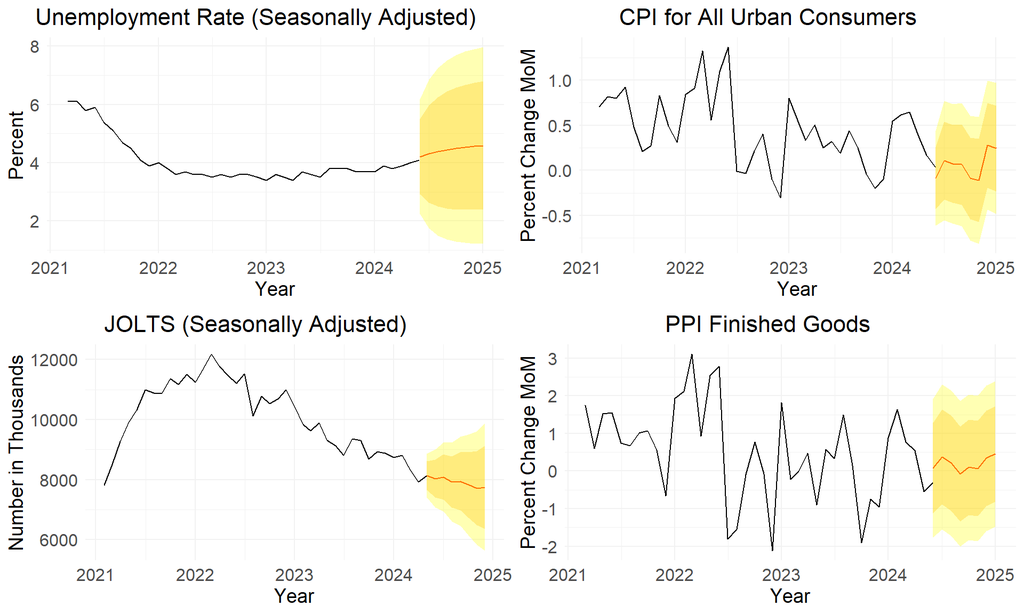

```r
#Example usage
arima_plots(series_names = c('LNS14000000','CUUR0000SA0','JTS000000000000000JOL','WPUFD49207'),
            titles =c('Unemployment Rate (Seasonally Adjusted)','CPI for All Urban Consumers',
                      'JOLTS (Seasonally Adjusted)','PPI Finished Goods'),
            include = 40,
            mom_growth_rate = c(FALSE,TRUE,FALSE,TRUE),
            yoy_growth_rate = c(FALSE,FALSE,FALSE,FALSE),
            ylabel = c('Percent','Percent Change MoM','Number in Thousands','Percent Change MoM'))
```

The arima_plots() function also allows year over year and monthly growth rates to be plotted as shown below:

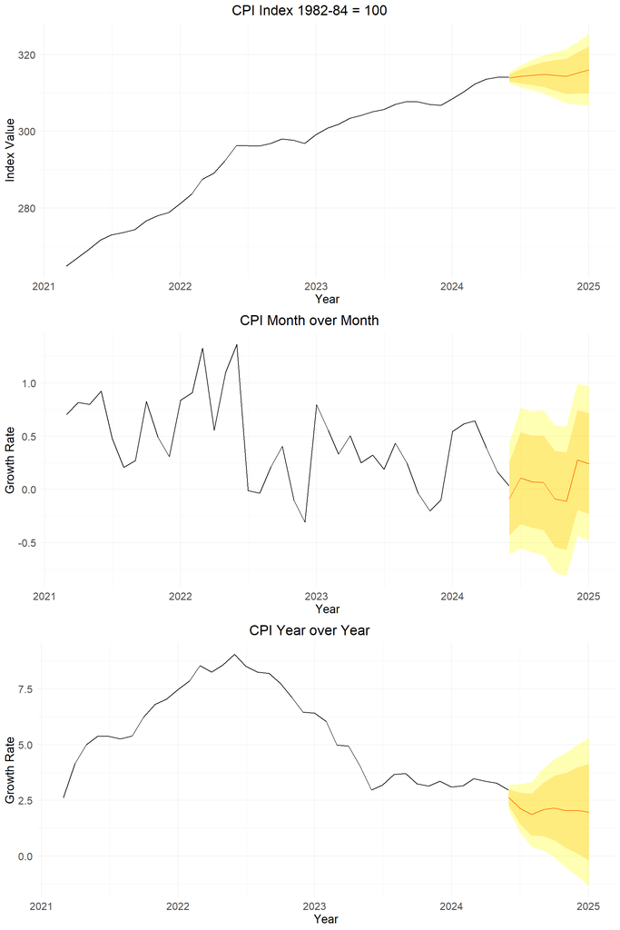

Summary Statistics for Each Series

| Series | CurrentValue | OneYearAvg | OneYearHigh | OneYearLow | Forecast1 | Forecast2 | Forecast3 |
| --- | --- | --- | --- | --- | --- | --- | --- |
| CPI Index 1982-84 = 100 | 314.18 | 309.57 | 314.18 | 305.69 | 313.94 | 314.34 | 314.6 |
| CPI Month over Month | 0.03 | 0.24 | 0.64 | -0.2 | -0.09 | 0.11 | 0.07 |
| CPI Year over Year | 2.97 | 3.3 | 3.7 | 2.97 | 2.63 | 2.14 | 1.86 |

```r
#Plotting CPI three different ways
arima_plots(series_names = c('CUUR0000SA0','CUUR0000SA0','CUUR0000SA0'),
            titles = c('CPI Index 1982-84 = 100','CPI Month over Month',
                       'CPI Year over Year'), ylabel = c('Index Value', 'Growth Rate', 'Growth Rate'),
            include = 40,
            mom_growth_rate = c(FALSE,TRUE,FALSE),
            yoy_growth_rate = c(FALSE,FALSE,TRUE),
            n_col = 1,
            summary = TRUE)
```

The arima_plots function makes creating economic outlook reports simple. The following example shows how one can generate such reports with only three lines of code.

## Economic Outlook Dashboard, July 2024

### Employment

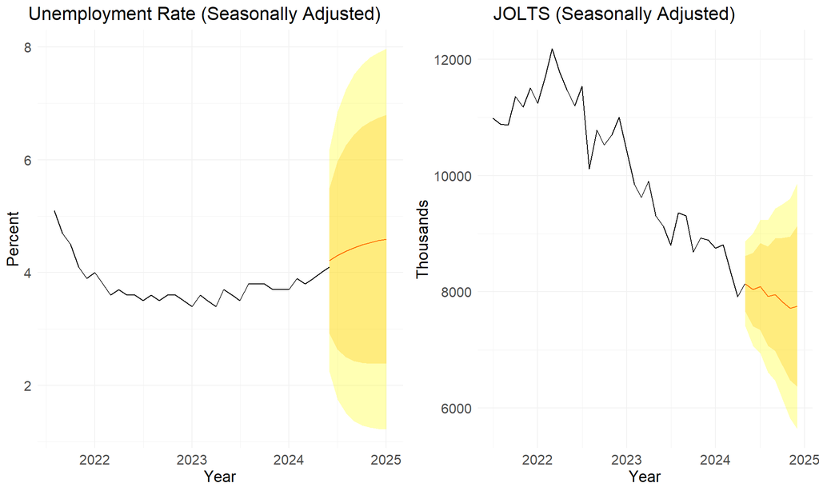

Summary Statistics for Each Series

| Series | CurrentValue | OneYearAvg | OneYearHigh | OneYearLow | Forecast1 | Forecast2 | Forecast3 |
| --- | --- | --- | --- | --- | --- | --- | --- |
| Unemployment Rate (Seasonally Adjusted) | 4.1 | 3.81 | 4.1 | 3.5 | 4.21 | 4.3 | 4.38 |
| JOLTS (Seasonally Adjusted) | 8140 | 8756.25 | 9358 | 7919 | 8139.09 | 8039.92 | 8093.51 |

### Productivity

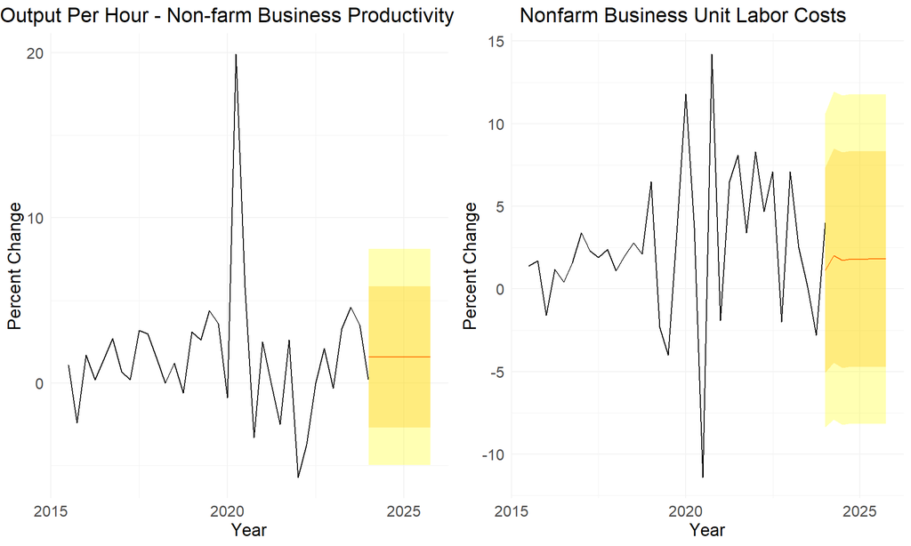

Summary Statistics for Each Series

| Series | CurrentValue | OneYearAvg | OneYearHigh | OneYearLow | Forecast1 | Forecast2 | Forecast3 |
| --- | --- | --- | --- | --- | --- | --- | --- |
| Output Per Hour - Non-farm Business Productivity | 0.2 | 0.33 | 4.6 | -5.7 | 1.59 | 1.59 | 1.59 |
| Nonfarm Business Unit Labor Costs | 4 | 3.92 | 8.3 | -2.8 | 1.14 | 2.02 | 1.75 |

### Inflation

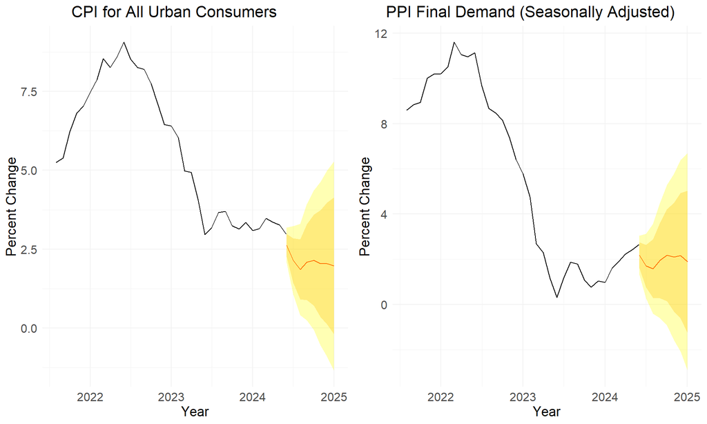

Summary Statistics for Each Series

| Series | CurrentValue | OneYearAvg | OneYearHigh | OneYearLow | Forecast1 | Forecast2 | Forecast3 |
| --- | --- | --- | --- | --- | --- | --- | --- |
| CPI for All Urban Consumers | 2.97 | 3.3 | 3.7 | 2.97 | 2.63 | 2.14 | 1.86 |
| PPI Final Demand (Seasonally Adjusted) | 2.65 | 1.63 | 2.65 | 0.77 | 2.18 | 1.71 | 1.59 |

### Appendix

```r
arima_plots = function(series_names,
                       titles = '',
                       autofit = TRUE, ### not yet available
                       seasonal = FALSE, ### not yet available
                       n_ahead = 8,
                       include = 20,
                       frequency = 'month',
                       ylabel = '',
                       mom_growth_rate=c(FALSE),
                       yoy_growth_rate = c(FALSE),
                       years_included = 9,
                       n_col=2,
                       summary = FALSE

){
  library(blsR)
  library(forecast)
  library(ggplot2)
  library(zoo)
  library(gridExtra)
  library(kableExtra)
  plot_list <<- list()

  summary_stats = data.frame(
    Series = character(length(series_names)),
    CurrentValue = numeric(length(series_names)),
    OneYearAvg = numeric(length(series_names)),
    OneYearHigh = numeric(length(series_names)),
    OneYearLow = numeric(length(series_names)),
    Forecast1 = numeric(length(series_names)),
    Forecast2 = numeric(length(series_names)),
    Forecast3 = numeric(length(series_names)),
    stringsAsFactors = FALSE
  )
  for (i in seq_along(series_names)){

    #manage start and end periods
    current_year = as.numeric(format(Sys.Date(), "%Y"))
    start_year = current_year - years_included

    #query series from BLS

    #querying one series at a time may not be the most efficient, however users without
    #an API key are limited to one series query at a time

    query = query_series(series_names[i],start_year = start_year, end_year = current_year)
    data = bls_request(query)
    data_as_table = data_as_tidy_table(data$series[[1]]$data)

    #manage frequency for time series conversion
    if (frequency == 'month') {
      frequency_num = 12
    } else if (frequency == 'quarter') {
      frequency_num = 4
    }

    #convert to time series
    series = ts(data_as_table$value, start = start_year,frequency = frequency_num)

    #calculate growth rate if specified in argument
    if (mom_growth_rate[i] ==TRUE){
      series = diff(log(series))*100
      series = na.omit(series)
    }
    if (yoy_growth_rate[i]==TRUE){
      series = (series / lag(series, -12) - 1) * 100
      series = na.omit(series)
    }
    #fit and forecast arima
    fit = auto.arima(series)
    forecast_data = forecast(fit, h=n_ahead)

    #prepare data for plotting - truncate to desired plotting length
    subset_data = tail(series,include)
    actual_data <- data.frame(
      Date = as.Date(as.yearmon(time(subset_data))),
      Value = as.numeric(subset_data)
    )

    #prepare dataframes for use with ggplot
    last_date = as.Date(as.yearmon(time(subset_data)[length(subset_data)]))

    forecast_dates = seq(last_date + 1, by = frequency, length.out = length(forecast_data$mean))

    forecast_data_frame <- data.frame(
      Date = forecast_dates,
      Forecast = as.numeric(forecast_data$mean),
      Lower80 = as.numeric(forecast_data$lower[,1]),
      Upper80 = as.numeric(forecast_data$upper[,1]),
      Lower95 = as.numeric(forecast_data$lower[,2]),
      Upper95 = as.numeric(forecast_data$upper[,2])
    )

    plot =ggplot() +
      geom_line(data = actual_data, aes(x = Date, y = Value), color = "black") +
      geom_line(data = forecast_data_frame, aes(x = Date, y = Forecast), color = "red") +
      geom_ribbon(data = forecast_data_frame, aes(x = Date, ymin = Lower80, ymax = Upper80), fill = "orange", alpha = 0.3) +
      geom_ribbon(data = forecast_data_frame, aes(x = Date, ymin = Lower95, ymax = Upper95), fill = "yellow", alpha = 0.3) +
      ggtitle(titles[i]) +
      xlab("Year") +
      ylab(ylabel[i]) +
      theme_minimal()+
      theme(
        plot.background = element_rect(fill = "white", color = NA),
        panel.background = element_rect(fill = "white", color = NA),
        panel.grid.major = element_line(color = "gray95"),
        panel.grid.minor = element_line(color = "gray95"),
        plot.title = element_text(size = 16,hjust = .5),
        plot.title.position = 'plot',
        axis.title.x = element_text(size = 14),
        axis.title.y = element_text(size = 14),
        axis.text = element_text(size = 12)
      )
    plot_list[[i]] <<- plot ### send plots to a global list so user can reproduce individually

      # Calculate summary statistics
    one_year_data = tail(series, 12)
    current_value = tail(series, 1)
    one_year_avg = mean(one_year_data, na.rm = TRUE)
    one_year_high = max(one_year_data, na.rm = TRUE)
    one_year_low = min(one_year_data, na.rm = TRUE)

      # Forecast values
    forecast_1 = ifelse(length(forecast_data$mean) >= 1, forecast_data$mean[1], NA)
    forecast_2 = ifelse(length(forecast_data$mean) >= 2, forecast_data$mean[2], NA)
    forecast_3 = ifelse(length(forecast_data$mean) >= 3, forecast_data$mean[3], NA)

      # Store summary statistics in the data frame
    summary_stats[i, ] = c(titles[i],
                            round(current_value, 2),
                            round(one_year_avg, 2),
                            round(one_year_high, 2),
                            round(one_year_low, 2),
                            round(forecast_1, 2),
                            round(forecast_2, 2),
                            round(forecast_3, 2))
}

    # Display the summary statistics table
  library(knitr)
  summary_stats[] <- lapply(summary_stats, as.character)  # Convert all columns to character for proper display

  #plot all plots
  do.call(grid.arrange, c(plot_list, ncol = n_col))
  if (summary==TRUE){
    print(
    kable(summary_stats, caption = "Summary Statistics for Each Series", align = 'c') %>%
    kable_styling(full_width = FALSE, position = "center", bootstrap_options = c("striped", "hover", "condensed", "responsive"))
  )
  }
}
```

Return